# Selenium_financialmodellingprep_show

```python
import pandas as pd
from IPython.display import display
import time
from selenium import webdriver
import pandas as pd
import pickle
import bz2
from tqdm import tqdm
import requests
from bs4 import BeautifulSoup
from datetime import datetime
import matplotlib.pyplot as plt
```

Yet another option we have for getting financial data from the internet is scrapping a website such as financialmodelingprep.com This website contains several tables within the same address but those tables aren't visible until you click on the on the screen. This is because the html contains javascripts that produce the table on the fly.

For our purposes this means that we need to use a webdriver to automate the click on a table. I will be using chromedriver.

The function defined below uses chromedriver to open either the yealy or quarterly financial data on financialmodelingprep.com and goes through three sets of tables 'Income Statement', 'Balance Sheet Statement', 'Cash Flow Statement' retrieving the tables with pandas read_html.

```python
def get_financials(ticker=None, quarterly=False,
                   chrome_path=r"C:\Users\victor.sequi\Downloads\chromedriver_win32\chromedriver.exe"):
    driver = webdriver.Chrome(chrome_path)
    if quarterly:
        url = f'https://financialmodelingprep.com/financial-statements-quarterly/{ticker}'
    else:
        url = f'https://financialmodelingprep.com/financial-statements/{ticker}'

    page = driver.get(url)
    Financials = []
    Financials_names = ['Income Statement', 'Retained Earning Schedule', 'PPE Schedule',
                        'Intangible and Goodwill Schedule', 'Balance Sheet Statement',
                        'Retained Earning Schedule', 'PPE Schedule', 'Intangible and Goodwill Schedule',
                        'Cash Flow Statement', 'Retained Earning Schedule', 'PPE Schedule',
                        'Intangible and Goodwill Schedule']

    for Hyper_link in driver.find_elements_by_class_name('item'):
        Hyper_link.click()
        for i, table in enumerate(pd.read_html(driver.page_source)):
            Financials.append(table)
        time.sleep(2)
    driver.close()
    Financials = dict(zip(Financials_names, Financials))
    response = requests.get(url)
    results_page = BeautifulSoup(response.content, 'lxml')
    Financials['price'] = float(results_page.find('div',
                                                  attrs={'class': 'company-price'}).contents[0].strip().strip('$'))
    return Financials
```

The cell below reads all the stocks available at Revolut, which I happen to use as a broker. It then uses the funciton defined previouly to retreive the data of the tickers available.

Once the data has been retreived it is saved on compressed pickles so that we don't have to go through this exercise everytime we want see the company financials. The financials are usually updated every quarter. Which implies that we shouldn't need to retrieve the data more than 4 times a year.

```python
Rev_stocks = pd.read_csv("../01 Data/RevStock.csv", encoding="ISO-8859-1")
All_Yearly_financials = {}


for ticker in tqdm(Rev_stocks.Ticker[:10]):
    Yearly_Financials = get_financials(ticker)
    All_Yearly_financials[ticker] = Yearly_Financials
    now = datetime.now().strftime("%d-%m-%y")
    file_to_write = bz2.BZ2File(f"../01 Data/stocks_dicts/{ticker}_{now}_Yearly_financials.pkl", "wb")
    pickle.dump(Yearly_Financials, file_to_write)
```

```python
now = datetime.now().strftime("%d-%m-%y")
file_to_write = bz2.BZ2File(f"../01 Data/stocks_dicts/{now}_All_Yearly_financials.pkl", "wb")
pickle.dump(All_Yearly_financials, file_to_write)
```

The next time we run the script we can skip the data collection part and run the cell below which is going to load the pickle saved data.

```python
infile = bz2.open("../01 Data/stocks_dicts/26-11-20_All_Yearly_financials.pkl", mode='rb')
All_Yearly_financials = pickle.load(infile)
```

After running the above we have a collection of dictionaries with the tables: 'Income Statement', 'Retained Earning Schedule', 'PPE Schedule', 'Intangible and Goodwill Schedule', 'Balance Sheet Statement', 'Cash Flow Statement', and 'price'

See below the data dictionary for Apple ticker:'APPL'

```python
All_Yearly_financials['AAPL']
```

```
{'Income Statement':                                              Year       2020       2019  \
 0                                         Revenue  274515.00  260174.00
 1                                 Cost of Revenue  169559.00  161782.00
 2                                    Gross Profit  104956.00   98392.00
 3                              Operating Expenses   38668.00   34462.00
 4                                Operating Income   66288.00   63930.00
 5                                Interest Expense          -    3576.00
 6                              Income Tax Expense    9680.00   10481.00
 7                             Earnings before Tax   67091.00   65737.00
 8                                      Net Income   57411.00   55256.00
 9                        Earnings Per Share Basic       3.31       2.97
 10                     Earnings Per Share Diluted       3.28       2.97
 11            Weighted Average Shares Outstanding   17352.12   18595.65
 12  Weighted Average Shares Outstanding (Diluted)   17528.21   18595.65
 13                             Dividend per Share          -          -
```

[output cut: 220 more lines]

If we only want to open the 'Income Statement' we can do so by running:

```python
All_Yearly_financials['AAPL']['Income Statement']
```

|  | Year | 2020 | 2019 | 2018 | 2017 | 2016 | 2015 | 2014 | 2013 | 2012 | 2011 |
| --- | --- | --- | --- | --- | --- | --- | --- | --- | --- | --- | --- |
| 0 | Revenue | 274515.00 | 260174.00 | 265595.00 | 229234.00 | 215639.00 | 233715.00 | 182795.00 | 170910.00 | 156508.00 | 108249.00 |
| 1 | Cost of Revenue | 169559.00 | 161782.00 | 163756.00 | 141048.00 | 131376.00 | 140089.00 | 112258.00 | 106606.00 | 87846.00 | 64431.00 |
| 2 | Gross Profit | 104956.00 | 98392.00 | 101839.00 | 88186.00 | 84263.00 | 93626.00 | 70537.00 | 64304.00 | 68662.00 | 43818.00 |
| 3 | Operating Expenses | 38668.00 | 34462.00 | 30941.00 | - | 24239.00 | 22396.00 | 18034.00 | 15305.00 | 13421.00 | 10028.00 |
| 4 | Operating Income | 66288.00 | 63930.00 | 70898.00 | 61344.00 | 60024.00 | 71230.00 | 52503.00 | 48999.00 | 55241.00 | 33790.00 |
| 5 | Interest Expense | - | 3576.00 | 3240.00 | 2323.00 | 1456.00 | 733.00 | 384.00 | 136.00 | 1088.00 | 519.00 |
| 6 | Income Tax Expense | 9680.00 | 10481.00 | 11872.00 | 15738.00 | 15685.00 | 19121.00 | 13973.00 | 13118.00 | 14030.00 | 8283.00 |
| 7 | Earnings before Tax | 67091.00 | 65737.00 | 72903.00 | 64089.00 | 61372.00 | 72515.00 | 53483.00 | 50155.00 | 55763.00 | 34205.00 |
| 8 | Net Income | 57411.00 | 55256.00 | 59531.00 | 48351.00 | 45687.00 | 53394.00 | 39510.00 | 37037.00 | 41733.00 | 25922.00 |
| 9 | Earnings Per Share Basic | 3.31 | 2.97 | 2.98 | 2.32 | 2.08 | 2.30 | 1.61 | 1.42 | 1.58 | 0.99 |
| 10 | Earnings Per Share Diluted | 3.28 | 2.97 | 2.98 | 2.30 | 2.08 | 2.30 | 1.61 | 1.42 | 1.58 | 0.99 |
| 11 | Weighted Average Shares Outstanding | 17352.12 | 18595.65 | 20000.44 | 20868.97 | 22001.12 | 23172.28 | 24492.00 | 26088.00 | 26468.00 | 26228.00 |
| 12 | Weighted Average Shares Outstanding (Diluted) | 17528.21 | 18595.65 | 20000.44 | 21006.77 | 22001.12 | 23172.28 | 24492.00 | 26088.00 | 26468.00 | 26228.00 |
| 13 | Dividend per Share | - | - | - | - | - | - | - | - | - | - |
| 14 | Gross Margin | 0.38 | 0.38 | 0.38 | 0.38 | 0.39 | 0.40 | 0.39 | 0.38 | 0.44 | 0.40 |
| 15 | EBIT Margin | 0.28 | 0.31 | 0.32 | 0.33 | 0.34 | 0.36 | 0.34 | 0.33 | 0.38 | 0.34 |
| 16 | Profit Margin | 0.21 | 0.21 | 0.22 | 0.21 | 0.21 | 0.23 | 0.22 | 0.22 | 0.27 | 0.24 |
| 17 | EBITDA | 77344.00 | 81860.00 | 85546.00 | 76569.00 | 73333.00 | 84505.00 | 61813.00 | 57048.00 | 60128.00 | 36538.00 |
| 18 | EBIT | 66288.00 | 69313.00 | 74643.00 | 76569.00 | 62828.00 | 73248.00 | 53867.00 | 50291.00 | 56851.00 | 34724.00 |
| 19 | NaN | NaN | NaN | NaN | NaN | NaN | NaN | NaN | NaN | NaN | NaN |
| 20 | Earnings Before Tax Margin | 0.24 | 0.25 | 0.27 | 0.28 | 0.28 | 0.31 | 0.29 | 0.29 | 0.36 | 0.32 |
| 21 | Net Profit Margin | 0.21 | 0.21 | 0.22 | 0.21 | 0.21 | 0.23 | 0.22 | 0.22 | 0.27 | 0.24 |

Personally I find it more useful to have the years as index. We can transpose the table to achieve this.

```python
def transpose(ticker_dict, table='Income Statement'):
    return ticker_dict[table].set_index('Year').T.apply(pd.to_numeric, errors='coerce')


transpose(All_Yearly_financials['AAPL'])
```

| Year | Revenue | Cost of Revenue | Gross Profit | Operating Expenses | Operating Income | Interest Expense | Income Tax Expense | Earnings before Tax | Net Income | Earnings Per Share Basic | ... | Weighted Average Shares Outstanding (Diluted) | Dividend per Share | Gross Margin | EBIT Margin | Profit Margin | EBITDA | EBIT | NaN | Earnings Before Tax Margin | Net Profit Margin |
| --- | --- | --- | --- | --- | --- | --- | --- | --- | --- | --- | --- | --- | --- | --- | --- | --- | --- | --- | --- | --- | --- |
| 2020 | 274515.0 | 169559.0 | 104956.0 | 38668.0 | 66288.0 | NaN | 9680.0 | 67091.0 | 57411.0 | 3.31 | ... | 17528.21 | NaN | 0.38 | 0.28 | 0.21 | 77344.0 | 66288.0 | NaN | 0.24 | 0.21 |
| 2019 | 260174.0 | 161782.0 | 98392.0 | 34462.0 | 63930.0 | 3576.0 | 10481.0 | 65737.0 | 55256.0 | 2.97 | ... | 18595.65 | NaN | 0.38 | 0.31 | 0.21 | 81860.0 | 69313.0 | NaN | 0.25 | 0.21 |
| 2018 | 265595.0 | 163756.0 | 101839.0 | 30941.0 | 70898.0 | 3240.0 | 11872.0 | 72903.0 | 59531.0 | 2.98 | ... | 20000.44 | NaN | 0.38 | 0.32 | 0.22 | 85546.0 | 74643.0 | NaN | 0.27 | 0.22 |
| 2017 | 229234.0 | 141048.0 | 88186.0 | NaN | 61344.0 | 2323.0 | 15738.0 | 64089.0 | 48351.0 | 2.32 | ... | 21006.77 | NaN | 0.38 | 0.33 | 0.21 | 76569.0 | 76569.0 | NaN | 0.28 | 0.21 |
| 2016 | 215639.0 | 131376.0 | 84263.0 | 24239.0 | 60024.0 | 1456.0 | 15685.0 | 61372.0 | 45687.0 | 2.08 | ... | 22001.12 | NaN | 0.39 | 0.34 | 0.21 | 73333.0 | 62828.0 | NaN | 0.28 | 0.21 |
| 2015 | 233715.0 | 140089.0 | 93626.0 | 22396.0 | 71230.0 | 733.0 | 19121.0 | 72515.0 | 53394.0 | 2.30 | ... | 23172.28 | NaN | 0.40 | 0.36 | 0.23 | 84505.0 | 73248.0 | NaN | 0.31 | 0.23 |
| 2014 | 182795.0 | 112258.0 | 70537.0 | 18034.0 | 52503.0 | 384.0 | 13973.0 | 53483.0 | 39510.0 | 1.61 | ... | 24492.00 | NaN | 0.39 | 0.34 | 0.22 | 61813.0 | 53867.0 | NaN | 0.29 | 0.22 |
| 2013 | 170910.0 | 106606.0 | 64304.0 | 15305.0 | 48999.0 | 136.0 | 13118.0 | 50155.0 | 37037.0 | 1.42 | ... | 26088.00 | NaN | 0.38 | 0.33 | 0.22 | 57048.0 | 50291.0 | NaN | 0.29 | 0.22 |
| 2012 | 156508.0 | 87846.0 | 68662.0 | 13421.0 | 55241.0 | 1088.0 | 14030.0 | 55763.0 | 41733.0 | 1.58 | ... | 26468.00 | NaN | 0.44 | 0.38 | 0.27 | 60128.0 | 56851.0 | NaN | 0.36 | 0.27 |
| 2011 | 108249.0 | 64431.0 | 43818.0 | 10028.0 | 33790.0 | 519.0 | 8283.0 | 34205.0 | 25922.0 | 0.99 | ... | 26228.00 | NaN | 0.40 | 0.34 | 0.24 | 36538.0 | 34724.0 | NaN | 0.32 | 0.24 |

10 rows × 22 columns

Now that we have collected the data we can calculate the different ratios that will help us valuate the company. For example:

```python
def key_financials(ticker_dict):
    key_fin = pd.DataFrame()
    key_fin['Shares Outstanding Diluted'] = transpose(ticker_dict)['Weighted Average Shares Outstanding (Diluted)']
    key_fin['EPS Diluted'] = transpose(ticker_dict)['Net Income'] / key_fin['Shares Outstanding Diluted']
    key_fin['P/E Diluted'] = ticker_dict['price'] / key_fin['EPS Diluted']
    key_fin['Dividend per share'] = -transpose(ticker_dict, table='Cash Flow Statement')['Dividend payments'] / key_fin['Shares Outstanding Diluted']
    key_fin['Debt/Equity'] = transpose(ticker_dict, table='Balance Sheet Statement')['Total debt'] / transpose(ticker_dict, table='Balance Sheet Statement')['Total shareholders equity']
    key_fin['BV Diluted'] = transpose(ticker_dict, table='Balance Sheet Statement')['Total shareholders equity'] / key_fin['Shares Outstanding Diluted']
    key_fin['P/BV Diluted'] = ticker_dict['price'] / key_fin['BV Diluted']
    key_fin['ROE'] = transpose(ticker_dict)['Net Income'] / transpose(ticker_dict, table='Balance Sheet Statement')['Total shareholders equity']
    key_fin['Current Ratio'] = transpose(ticker_dict, table='Balance Sheet Statement')['Total assets'] / transpose(ticker_dict, table='Balance Sheet Statement')['Total liabilities']
    key_fin['Retained Earnings Diff'] = transpose(All_Yearly_financials['AAPL'], table='Retained Earning Schedule')['Retained Earnings'] - transpose(All_Yearly_financials['AAPL'], table='Retained Earning Schedule')['Retained Earnings (Previous Year)']
    key_fin.sort_index(inplace=True)
    return key_fin


key_financials(All_Yearly_financials['AAPL'])
```

|  | Shares Outstanding Diluted | EPS Diluted | P/E Diluted | Dividend per share | Debt/Equity | BV Diluted | P/BV Diluted | ROE | Current Ratio | Retained Earnings Diff |
| --- | --- | --- | --- | --- | --- | --- | --- | --- | --- | --- |
| 2011 | 26228.00 | 0.988333 | 117.399693 | NaN | NaN | 2.921115 | 39.721136 | 0.338341 | 2.927130 | NaN |
| 2012 | 26468.00 | 1.576734 | 73.588816 | 0.094000 | NaN | 4.466148 | 25.979884 | 0.353041 | 3.043247 | 38448.0 |
| 2013 | 26088.00 | 1.419695 | 81.728829 | 0.404937 | 0.137273 | 4.735856 | 24.500325 | 0.299776 | 2.480498 | 2967.0 |
| 2014 | 24492.00 | 1.613180 | 71.926266 | 0.454271 | 0.316414 | 4.554426 | 25.476317 | 0.354200 | 1.927302 | -17104.0 |
| 2015 | 23172.28 | 2.304219 | 50.355464 | 0.498915 | 0.538964 | 5.150766 | 22.526745 | 0.447355 | 1.698023 | 5132.0 |
| 2016 | 22001.12 | 2.076576 | 55.875631 | 0.552245 | 0.678617 | 5.829203 | 19.904950 | 0.356237 | 1.663001 | 4080.0 |
| 2017 | 21006.77 | 2.301687 | 50.410861 | 0.607852 | 0.862981 | 6.381133 | 18.183290 | 0.360702 | 1.555585 | 1966.0 |
| 2018 | 20000.44 | 2.976485 | 38.982229 | 0.685585 | 1.068467 | 5.357232 | 21.658572 | 0.555601 | 1.414370 | -27930.0 |
| 2019 | 18595.65 | 2.971448 | 39.048307 | 0.759264 | 1.194048 | 4.866084 | 23.844634 | 0.610645 | 1.364830 | -24502.0 |
| 2020 | 17528.21 | 3.275349 | 35.425236 | 0.803334 | 1.644347 | 3.727648 | 31.126865 | 0.878664 | 1.252714 | -30932.0 |

A quick an fun way to form an idea of what type of company we are assesing, in financial terms, is to plot the evolution over time of different ratios and indicators.

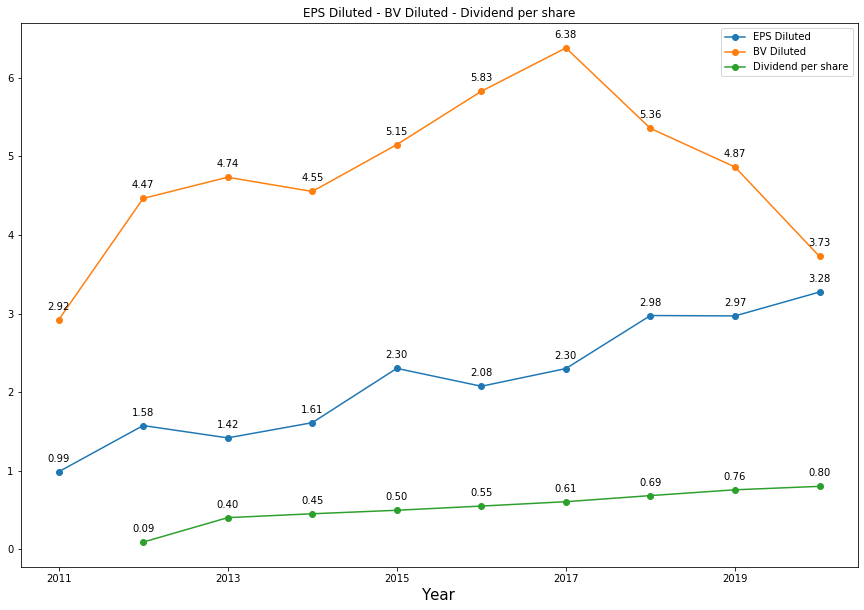

```python
key_fin = key_financials(All_Yearly_financials['AAPL'])


def plots(key_fin, cols_to_plot=['EPS Diluted', 'BV Diluted']):

    ax = key_fin[cols_to_plot].plot(figsize=(15, 10),
                                    title=' - '.join(cols_to_plot), marker='o')

    for col in cols_to_plot:
        for i, y in enumerate(key_fin[col]):
            x = i
            y = key_fin[col][i]
            label = "{:.2f}".format(y)
            ax.annotate(label,  # this is the text
                        (x, y),  # this is the point to label
                        textcoords="offset pixels",  # how to position the text
                        xytext=(0, 10),  # distance from text to points (x,y)
                        ha='center')  # horizontal alignment can be left, right or center
            ax.set_xlabel("Year", fontsize=15)
    display(ax)


plots(key_fin, cols_to_plot=['EPS Diluted', 'BV Diluted', 'Dividend per share'])
```

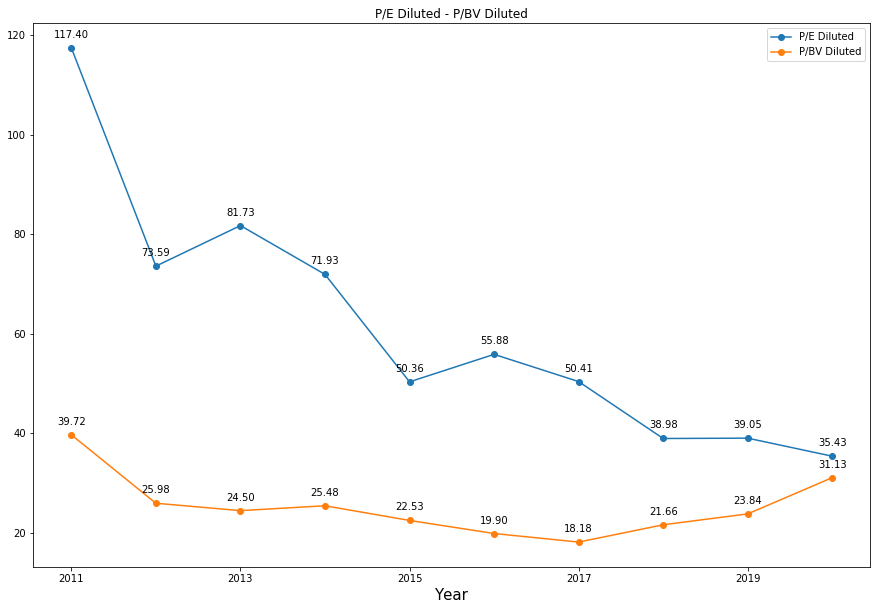

```python
plots(key_fin, cols_to_plot=['P/E Diluted', 'P/BV Diluted'])
```

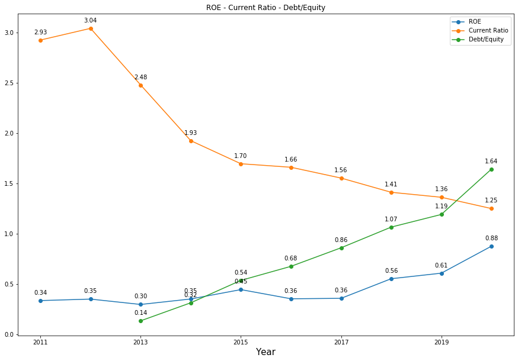

```python
plots(key_fin, cols_to_plot=['ROE', 'Current Ratio', 'Debt/Equity'])
```